# PRDM14 Gene Expression Analysis Code

This file contains the code used analyze the DataSet_01_045.txt file, which was downloaded from https://bio.liclab.net/KnockTFv2/download.php (search GSE22795). This dataset contains gene expression data from a study that investigated the gene changes after PRDM14 knockdown in human embryonic stem cells (hESCs).

```r
if (!require("BiocManager", quietly = TRUE))
    install.packages("BiocManager")

BiocManager::install("EnhancedVolcano")
n

library(DESeq2)
library(ggplot2)
library(pheatmap)
library(EnhancedVolcano)

packageVersion("DESeq2")
```

```
[1] ‘1.42.0’
```

**Step 1. Download Dataset**

```r
# source: https://bio.liclab.net/KnockTFv2/download.php, search GSE22795
# read in txt file
data3 <- read.table("DataSet_01_045.txt", header = TRUE, sep = "\t")
head(data3)
```

|  | Gene_Symbol | GSM563542 | GSM563543 | GSM563544 | GSM563545 | GSM563546 | GSM563547 |
| --- | --- | --- | --- | --- | --- | --- | --- |
| 1 | EEF1A1 | 29647.78333 | 32014.98000 | 39288.87667 | 41209.95333 | 32362.74000 | 41478.65333 |
| 2 | GAPDH | 9917.20900 | 9796.78500 | 12978.71333 | 11346.77367 | 11507.49067 | 12657.14667 |
| 3 | SLC35E2 | 80.11978 | 85.67426 | 62.96347 | 73.26114 | 77.10976 | 72.30206 |
| 4 | DUSP22 | 610.26695 | 663.71023 | 657.43781 | 606.06975 | 614.55974 | 570.92350 |
| 5 | RPS28 | 10081.51000 | 9967.25000 | 13624.35000 | 12189.98000 | 11208.90000 | 13774.60000 |
| 6 | IPO13 | 196.14270 | 157.66490 | 157.78780 | 172.70160 | 183.02030 | 171.58740 |

```r
str(data3)
```

```
'data.frame':   16671 obs. of  7 variables:
 $ Gene_Symbol: chr  "EEF1A1" "GAPDH" "SLC35E2" "DUSP22" ...
 $ GSM563542  : num  29647.8 9917.2 80.1 610.3 10081.5 ...
 $ GSM563543  : num  32015 9796.8 85.7 663.7 9967.2 ...
 $ GSM563544  : num  39289 12979 63 657 13624 ...
 $ GSM563545  : num  41210 11346.8 73.3 606.1 12190 ...
 $ GSM563546  : num  32362.7 11507.5 77.1 614.6 11208.9 ...
 $ GSM563547  : num  41478.7 12657.1 72.3 570.9 13774.6 ...
```

```r
summary(data3)
```

```
 Gene_Symbol          GSM563542          GSM563543          GSM563544          GSM563545
 Length:16671       Min.   :   45.22   Min.   :   35.76   Min.   :   33.24   Min.   :   38.86
 Class :character   1st Qu.:   72.18   1st Qu.:   69.18   1st Qu.:   68.59   1st Qu.:   68.83
 Mode  :character   Median :  109.17   Median :  107.70   Median :  107.34   Median :  109.26
                    Mean   :  556.42   Mean   :  568.85   Mean   :  628.54   Mean   :  623.58
                    3rd Qu.:  359.61   3rd Qu.:  360.58   3rd Qu.:  367.71   3rd Qu.:  379.08
                    Max.   :29647.78   Max.   :33451.62   Max.   :39288.88   Max.   :41209.95
   GSM563546          GSM563547
 Min.   :   40.11   Min.   :   39.58
 1st Qu.:   69.14   1st Qu.:   70.41
 Median :  109.52   Median :  109.12
 Mean   :  602.60   Mean   :  639.92
 3rd Qu.:  374.27   3rd Qu.:  372.39
 Max.   :32362.74   Max.   :41478.65
```

**Step 2. Data Cleaning/Pre-Processing**

```r
# rename columns
colnames(data3) <- c("Gene_Symbol", "Luci_KD1", "Luci_KD2", "Luci_KD3", "PRDM14_KD1", "PRDM14_KD2", "PRDM14_KD3")
head(data3)
```

|  | Gene_Symbol | Luci_KD1 | Luci_KD2 | Luci_KD3 | PRDM14_KD1 | PRDM14_KD2 | PRDM14_KD3 |
| --- | --- | --- | --- | --- | --- | --- | --- |
| 1 | EEF1A1 | 29647.78333 | 32014.98000 | 39288.87667 | 41209.95333 | 32362.74000 | 41478.65333 |
| 2 | GAPDH | 9917.20900 | 9796.78500 | 12978.71333 | 11346.77367 | 11507.49067 | 12657.14667 |
| 3 | SLC35E2 | 80.11978 | 85.67426 | 62.96347 | 73.26114 | 77.10976 | 72.30206 |
| 4 | DUSP22 | 610.26695 | 663.71023 | 657.43781 | 606.06975 | 614.55974 | 570.92350 |
| 5 | RPS28 | 10081.51000 | 9967.25000 | 13624.35000 | 12189.98000 | 11208.90000 | 13774.60000 |
| 6 | IPO13 | 196.14270 | 157.66490 | 157.78780 | 172.70160 | 183.02030 | 171.58740 |

```r
sum(duplicated(data3)) # no duplicates
```

```
[1] 0
```

```r
which(is.na(data3)) # no NAs
```

```
integer(0)
```

```r
genenames <- data3$Gene_Symbol
head(genenames)
```

```
[1] "EEF1A1"  "GAPDH"   "SLC35E2" "DUSP22"  "RPS28"   "IPO13"
```

```r
data3 <- data3[,2:7]
rownames(data3) <- genenames
```

```r
data3 <- as.matrix(data3)
class(data3)
```

```
[1] "matrix" "array"
```

```r
# define experimental condition - treatment or control
coldata <- data.frame("condition"=as.factor(c(rep("Control",3), rep("Treatment",3))), row.names=colnames(data3))
```

```r
head(data3)
```

```
           Luci_KD1    Luci_KD2    Luci_KD3  PRDM14_KD1  PRDM14_KD2  PRDM14_KD3
EEF1A1  29647.78333 32014.98000 39288.87667 41209.95333 32362.74000 41478.65333
GAPDH    9917.20900  9796.78500 12978.71333 11346.77367 11507.49067 12657.14667
SLC35E2    80.11978    85.67426    62.96347    73.26114    77.10976    72.30206
DUSP22    610.26695   663.71023   657.43781   606.06975   614.55974   570.92350
RPS28   10081.51000  9967.25000 13624.35000 12189.98000 11208.90000 13774.60000
IPO13     196.14270   157.66490   157.78780   172.70160   183.02030   171.58740
```

**Step 3. Gene Expression Analysis**

```r
library("heatmap3")
pdf("Heatmap.pdf")
heatmap3(cor(data3), symm = TRUE, mar = c(10, 10))
dev.off()
```

```r
#sparse inverse covariance
library(glasso)
inv<-glasso(var(data3),rho=0.01)$wi
inv[inv>3]<- 3
rownames(inv)<-colnames(data3)
colnames(inv)<-colnames(data3)
pdf("SparseInverseCovariance.pdf")
heatmap3(inv,symm=TRUE, mar = c(10, 10))
dev.off()
```

```r
dds <- DESeqDataSetFromMatrix(countData = round(data3), colData = coldata, design = ~ condition)
dds
```

```
class: DESeqDataSet
dim: 16671 6
metadata(1): version
assays(1): counts
rownames(16671): EEF1A1 GAPDH ... TOX3 MCM10
rowData names(0):
colnames(6): Luci_KD1 Luci_KD2 ... PRDM14_KD2 PRDM14_KD3
colData names(1): condition
```

```r
dds <- DESeq(dds)
```

```r
normal_counts <- counts(dds, normalized = TRUE)
head(normal_counts)
```

```
           Luci_KD1    Luci_KD2   Luci_KD3 PRDM14_KD1  PRDM14_KD2 PRDM14_KD3
EEF1A1  28889.78418 32195.37942 39397.0145 41697.5740 32630.97981 41302.5421
GAPDH    9663.38336  9852.19841 13014.6823 11481.2515 11602.28300 12603.1552
SLC35E2    77.95409    86.48454    63.1732    73.8637    77.63759    71.6937
DUSP22    594.39990   667.74112   658.8062   613.1699   620.09247   568.5709
RPS28    9824.16366 10023.15623 13661.4555 12334.2254 11301.81543 13716.3991
IPO13     190.98751   158.89021   158.4344   175.0468   184.51532   171.2683
```

```r
write.csv(normal_counts, file = "normal_counts.csv")
```

```r
res <- results(dds, contrast = c("condition", "Treatment", "Control"), alpha = 0.05)
res
```

```
log2 fold change (MLE): condition Treatment vs Control
Wald test p-value: condition Treatment vs Control
DataFrame with 16671 rows and 6 columns
          baseMean log2FoldChange     lfcSE       stat      pvalue        padj
         <numeric>      <numeric> <numeric>  <numeric>   <numeric>   <numeric>
EEF1A1  36018.8790      0.2025947  0.133427   1.518399    0.128914    0.236149
GAPDH   11369.4923      0.1336181  0.124100   1.076698    0.281615    0.434834
SLC35E2    75.1345     -0.0284851  0.183831  -0.154953    0.876858          NA
DUSP22    620.4634     -0.0922344  0.110626  -0.833749    0.404422    0.567461
RPS28   11810.2025      0.1566779  0.134167   1.167784    0.242894    0.387853
...            ...            ...       ...        ...         ...         ...
TAAR2      63.6467      0.0164938  0.193630  0.0851821 9.32117e-01          NA
TMEM107    87.4711     -0.2208235  0.173178 -1.2751244 2.02265e-01 3.36693e-01
STIL     1146.0911     -0.3442878  0.107501 -3.2026464 1.36171e-03 4.56326e-03
TOX3      109.9820      0.7262115  0.163897  4.4308929 9.38437e-06 4.88950e-05
MCM10     583.8677     -0.8554697  0.114059 -7.5002656 6.36886e-14 8.74428e-13
```

```r
write.csv(res, file = "res.csv")
```

```r
summary(res)
```

```
out of 16671 with nonzero total read count
adjusted p-value < 0.05
LFC > 0 (up)       : 2341, 14%
LFC < 0 (down)     : 2215, 13%
outliers [1]       : 0, 0%
low counts [2]     : 5495, 33%
(mean count < 75)
[1] see 'cooksCutoff' argument of ?results
[2] see 'independentFiltering' argument of ?results
```

```r
# create scatter plot of differential expression from normal_counts dataframe, where x-axis is gene expression level of controls and y-axis is treatment

# Luci_KD1 vs. PRDM14_KD1
plot(normal_counts[,1], normal_counts[,4], xlab = "Control", ylab = "PRDM14 Knockdown", main = "Scatter Plot of Differential Expression", xlim = c(0, 10000), ylim = c(0, 10000))

# Luci_KD2 vs. PRDM14_KD2
points(normal_counts[,2], normal_counts[,5])
```

```r
# Luci_KD3 vs. PRDM14_KD3
points(normal_counts[,3], normal_counts[,6])

# draw a line at y = x
abline(0, 1)
```

```r
# highlight upregulated genes in green
points(normal_counts[which(res$log2FoldChange > 1),1], normal_counts[which(res$log2FoldChange > 1),4], col = "green")
points(normal_counts[which(res$log2FoldChange > 1),2], normal_counts[which(res$log2FoldChange > 1),5], col = "green")
```

```r
points(normal_counts[which(res$log2FoldChange > 1),3], normal_counts[which(res$log2FoldChange > 1),6], col = "green")

# highlight downregulated genes in purple
points(normal_counts[which(res$log2FoldChange < -1),1], normal_counts[which(res$log2FoldChange < -1),4], col = "purple")
```

```r
points(normal_counts[which(res$log2FoldChange < -1),2], normal_counts[which(res$log2FoldChange < -1),5], col = "purple")
points(normal_counts[which(res$log2FoldChange < -1),3], normal_counts[which(res$log2FoldChange < -1),6], col = "purple")
```

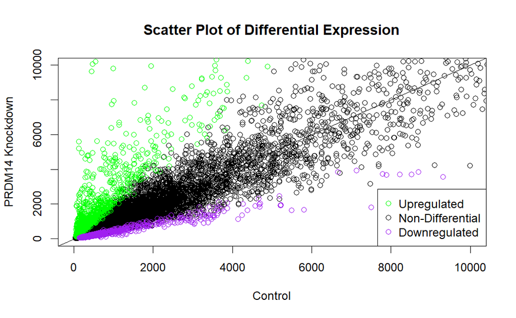

```r
# add legend
legend("bottomright", legend = c("Upregulated", "Non-Differential", "Downregulated"), col = c("green","black", "purple"), pch = 1)
```

```r
# which gene names were green?
green_genes <- row.names(normal_counts[which(res$log2FoldChange > 1),])
head(green_genes)
```

```
[1] "LPP"     "COL17A1" "SPP1"    "SYTL2"   "MKL1"    "EHD1"
```

```r
length(green_genes)
```

```
[1] 542
```

```r
# which gene names were purple?
purple_genes <- row.names(normal_counts[which(res$log2FoldChange < -1),])
head(purple_genes)
```

```
[1] "DIAPH2"  "ZSCAN2"  "MYCN"    "NUDT1"   "HEYL"    "ZDHHC22"
```

```r
length(purple_genes)
```

```
[1] 209
```

```r
# which gene names were black? (total genes - puiple genes - green genes)
black_genes <- row.names(normal_counts[which(res$log2FoldChange < 1 & res$log2FoldChange > -1),])
head(black_genes)
```

```
[1] "EEF1A1"  "GAPDH"   "SLC35E2" "DUSP22"  "RPS28"   "IPO13"
```

```r
length(black_genes)
```

```
[1] 15920
```

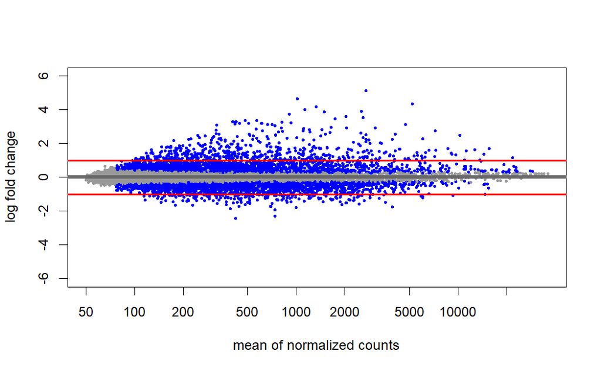

```r
# make an MA plot to visualize gene expression changes

plotMA(res, cex = 0.5, ylim=c(-6,6))
abline(h = c(-1, 1), col = "red", lwd = 2)
```

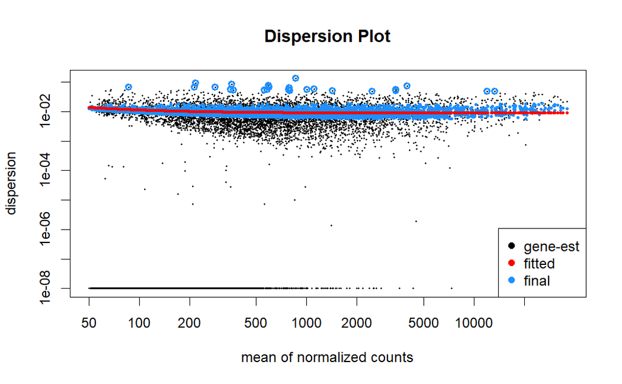

```r
# Create dispersion plot
plotDispEsts(dds, main="Dispersion Plot")
```

```r
# PCA plot
rld <- rlogTransformation(dds, blind=FALSE)
head(assay(rld))
```

```
         Luci_KD1  Luci_KD2  Luci_KD3 PRDM14_KD1 PRDM14_KD2 PRDM14_KD3
EEF1A1  14.873943 15.001432 15.240297  15.307741  15.017284  15.296421
GAPDH   13.279711 13.302461 13.631408  13.482866  13.495266  13.593275
SLC35E2  6.263144  6.358484  6.080925   6.214803   6.259242   6.188514
DUSP22   9.227972  9.360632  9.345221   9.263321   9.276092   9.177769
RPS28   13.308595 13.332155 13.698071  13.576860  13.473534  13.702842
IPO13    7.538084  7.347155  7.344216   7.446509   7.501476   7.423915
```

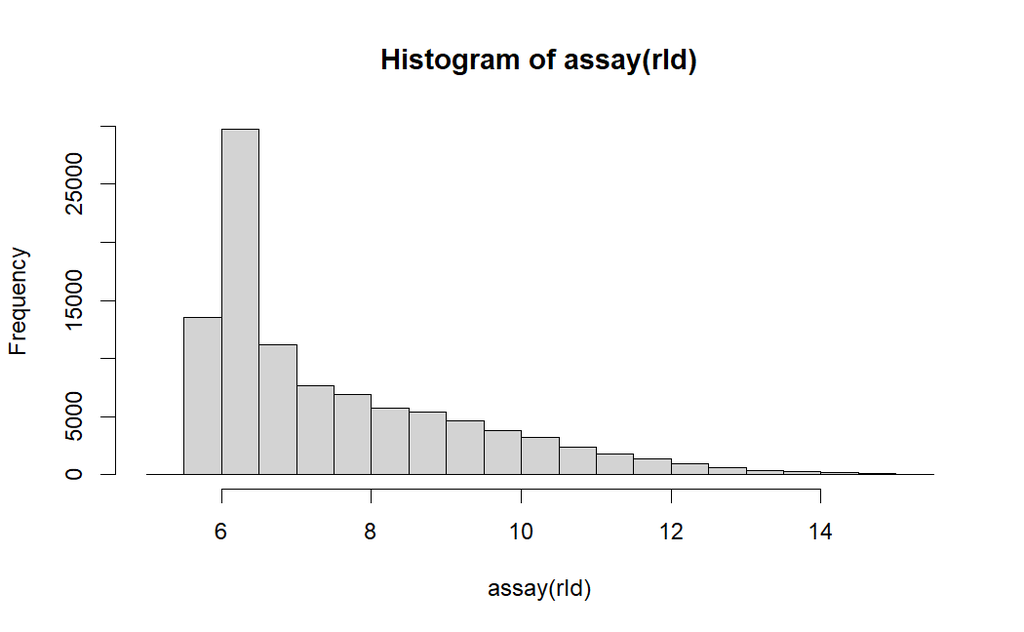

```r
hist(assay(rld))
```

```r
PCAA <- plotPCA(rld, intgroup=c("condition"))
```

```
using ntop=500 top features by variance
```

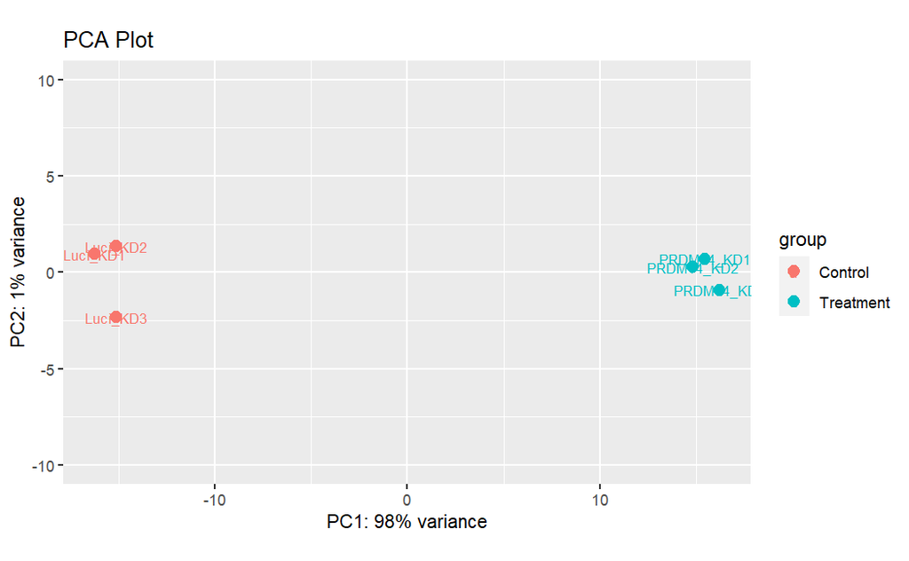

```r
PCAA + geom_text(aes(label=name), size=3) + ggtitle("PCA Plot") + ylim(-10, 10)
```

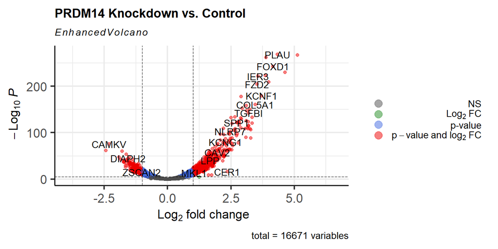

```r
EnhancedVolcano(res,
                lab = rownames(res),
                x = 'log2FoldChange',
                y = 'pvalue',
                title = 'PRDM14 Knockdown vs. Control',
                legendPosition = 'right')
```

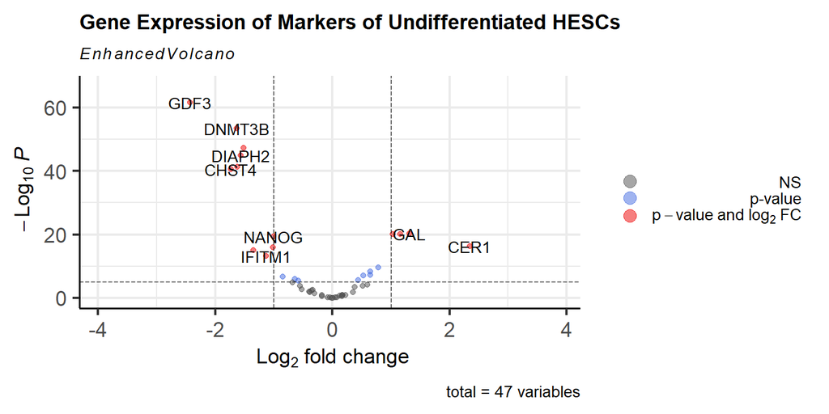

```r
# create volcano plot for:
# markers of undifferentiated ESCs: "LIN28", "DNMT3B", "CLDN6", "IFITM1", "POU5F1", "ITGB1", "SFRP2", "GJA1", "SOX2", "CD9", "GAL", "LIN41", "IMP-2", "LECT1", "ZNF206", "GABRB3", "CYLTLIB", "UTF1", "NR6A1", "LEFTY1", "SCGB3A2", "KIT", "CKMT1", "TDGF1", "FOXD3", "DIAPH2", "NUMB", "CER1", "PMAIP1", "CDH1", "LEFTY2", "NANOG", "SMAD2", "BRIX", "REST", "ZFP42", "EDNRB", "PTEN", "NOG", "GDF3", "GBX2", "TFCP2L1", "COMMD3", "TERT", "PODXL", "FGF4", "NR5A2", "IFITM2", "GRB7", "DPPA5", "NODAL", "LCK", "NTS", "ITGBIBP3", "CHST4"



# filter res df for genes of interest
genes_of_interest <- res[rownames(res) %in% c("LIN28", "DNMT3B", "CLDN6", "IFITM1", "POU5F1", "ITGB1", "SFRP2", "GJA1", "SOX2", "CD9", "GAL", "LIN41", "IMP-2", "LECT1", "ZNF206", "GABRB3", "CYLTLIB", "UTF1", "NR6A1", "LEFTY1", "SCGB3A2", "KIT", "CKMT1", "TDGF1", "FOXD3", "DIAPH2", "NUMB", "CER1", "PMAIP1", "CDH1", "LEFTY2", "NANOG", "SMAD2", "BRIX", "REST", "ZFP42", "EDNRB", "PTEN", "NOG", "GDF3", "GBX2", "TFCP2L1", "COMMD3", "TERT", "PODXL", "FGF4", "NR5A2", "IFITM2", "GRB7", "DPPA5", "NODAL", "LCK", "NTS", "ITGBIBP3", "CHST4"),]


# create volcano plot, label all genes
EnhancedVolcano(genes_of_interest,
                lab = rownames(genes_of_interest),
                x = 'log2FoldChange',
                y = 'pvalue',
                title = 'Gene Expression of Markers of Undifferentiated HESCs',
                legendPosition = 'right')
```

```r
NA
NA
```

```r
# which gene names were downregulated in the genes of interest?
downregulated_genes <- row.names(normal_counts[which(res$log2FoldChange < -1 & rownames(res) %in% c("LIN28", "DNMT3B", "CLDN6", "IFITM1", "POU5F1", "ITGB1", "SFRP2", "GJA1", "SOX2", "CD9", "GAL", "LIN41", "IMP-2", "LECT1", "ZNF206", "GABRB3", "CYLTLIB", "UTF1", "NR6A1", "LEFTY1", "SCGB3A2", "KIT", "CKMT1", "TDGF1", "FOXD3", "DIAPH2", "NUMB", "CER1", "PMAIP1", "CDH1", "LEFTY2", "NANOG", "SMAD2", "BRIX", "REST", "ZFP42", "EDNRB", "PTEN", "NOG", "GDF3", "GBX2", "TFCP2L1", "COMMD3", "TERT", "PODXL", "FGF4", "NR5A2", "IFITM2", "GRB7", "DPPA5", "NODAL", "LCK", "NTS", "ITGBIBP3", "CHST4")),])
downregulated_genes
```

```
 [1] "DIAPH2" "NANOG"  "IFITM2" "CHST4"  "LECT1"  "DNMT3B" "SOX2"   "IFITM1" "DPPA5"  "GDF3"
```

```r
# which gene names were upregulated in the genes of interest?
upregulated_genes <- row.names(normal_counts[which(res$log2FoldChange > 1 & rownames(res) %in% c("LIN28", "DNMT3B", "CLDN6", "IFITM1", "POU5F1", "ITGB1", "SFRP2", "GJA1", "SOX2", "CD9", "GAL", "LIN41", "IMP-2", "LECT1", "ZNF206", "GABRB3", "CYLTLIB", "UTF1", "NR6A1", "LEFTY1", "SCGB3A2", "KIT", "CKMT1", "TDGF1", "FOXD3", "DIAPH2", "NUMB", "CER1", "PMAIP1", "CDH1", "LEFTY2", "NANOG", "SMAD2", "BRIX", "REST", "ZFP42", "EDNRB", "PTEN", "NOG", "GDF3", "GBX2", "TFCP2L1", "COMMD3", "TERT", "PODXL", "FGF4", "NR5A2", "IFITM2", "GRB7", "DPPA5", "NODAL", "LCK", "NTS", "ITGBIBP3", "CHST4")),])
upregulated_genes
```

```
[1] "GAL"    "CER1"   "ITGB1"  "LEFTY2"
```

[figure not shown]

```r
# create volcano plot for:
# Ectoderm markers: VIM, CRABP2, SEMA3A, MSI1, MAP2, GFAP, OLIG2, SOX1, NES, NEUROD1, TH, TUBB3
# filter res df for genes of interest
ectoderm_markers <- res[rownames(res) %in% c("VIM", "CRABP2", "SEMA3A", "MSI1", "MAP2", "GFAP", "OLIG2", "SOX1", "NES", "NEUROD1", "TH", "TUBB3"),]


# create volcano plot, label all genes
EnhancedVolcano(ectoderm_markers,
                lab = rownames(ectoderm_markers),
                x = 'log2FoldChange',
                y = 'pvalue',
                title = 'Gene Expression of Ectoderm Markers',
                legendPosition = 'right')
```

```r
NA
NA
```

```r
# which gene names were downregulated in the ectoderm markers?
downregulated_genes <- row.names(normal_counts[which(res$log2FoldChange < -1 & rownames(res) %in% c("VIM", "CRABP2", "SEMA3A", "MSI1", "MAP2", "GFAP", "OLIG2", "SOX1", "NES", "NEUROD1", "TH", "TUBB3")),])
downregulated_genes
```

[output not shown]

```r
# which gene names were upregulated in the ectoderm markers?
upregulated_genes <- row.names(normal_counts[which(res$log2FoldChange > 1 & rownames(res) %in% c("VIM", "CRABP2", "SEMA3A", "MSI1", "MAP2", "GFAP", "OLIG2", "SOX1", "NES", "NEUROD1", "TH", "TUBB3")),])
upregulated_genes
```

```
[1] "CRABP2" "NES"    "VIM"    "TUBB3"
```

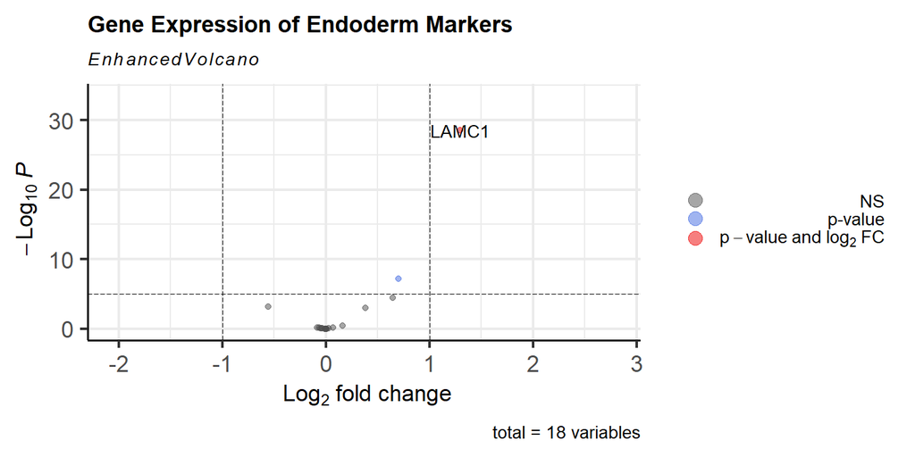

```r
# create volcano plot for:
# endoderm markers: "FN1", "DCN", "H19", "AFP", "LAMB1", "LAMC1", "BMP2", "SERPINA1", "FLT1", "ACVRIB", "GATA4", "GCG", "INS", "PECAM1", "FABP2", "HNF4A", "FGF8", "HGF", "FOXA2"
# filter res df for genes of interest
endoderm_markers <- res[rownames(res) %in% c("FN1", "DCN", "H19", "AFP", "LAMB1", "LAMC1", "BMP2", "SERPINA1", "FLT1", "ACVRIB", "GATA4", "GCG", "INS", "PECAM1", "FABP2", "HNF4A", "FGF8", "HGF", "FOXA2"),]


# create volcano plot, label all genes
EnhancedVolcano(endoderm_markers,
                lab = rownames(endoderm_markers),
                x = 'log2FoldChange',
                y = 'pvalue',
                title = 'Gene Expression of Endoderm Markers',
                legendPosition = 'right')
```

```r
NA
NA
```

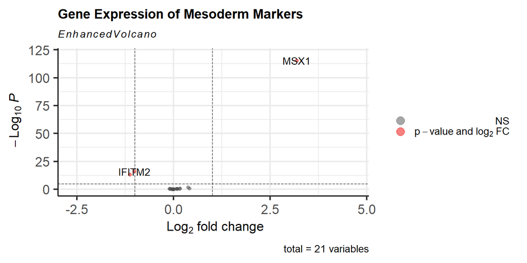

```r
# create volcano plot for:
# mesoderm markers: "FN1", "DCN", "H19", "AFP", "LAMB1", "LAMC1", "BMP2", "SERPINA1", "FLT1", "ACVRIB", "GATA4", "GCG", "INS", "PECAM1", "FABP2", "HNF4A", "FGF8", "HGF", "FOXA2"
# filter res df for genes of interest
mesoderm_markers <- res[rownames(res) %in% c("COLIA1", "HAND1", "MSX1", "ACTC", "GATA6", "COL2A1", "HBZ", "T", "WT1", "MYF5", "DES", "NPPA", "HBB", "RUNX2", "IGF2", "EOMES", "CDX2", "GCM1", "KRT1", "SYCP3", "DDX4", "IFITM1", "IFITM2"),]


# create volcano plot, label all genes
EnhancedVolcano(mesoderm_markers,
                lab = rownames(mesoderm_markers),
                x = 'log2FoldChange',
                y = 'pvalue',
                title = 'Gene Expression of Mesoderm Markers',
                legendPosition = 'right')
```

```r
NA
NA
```

```r
# which gene names were downregulated in the mesoderm markers?
downregulated_genes <- row.names(normal_counts[which(res$log2FoldChange < -1 & rownames(res) %in% c("COLIA1", "HAND1", "MSX1", "ACTC", "GATA6", "COL2A1", "HBZ", "T", "WT1", "MYF5", "DES", "NPPA", "HBB", "RUNX2", "IGF2", "EOMES", "CDX2", "GCM1", "KRT1", "SYCP3", "DDX4", "IFITM1", "IFITM2")),])
downregulated_genes
```

```
[1] "IFITM2" "IFITM1"
```

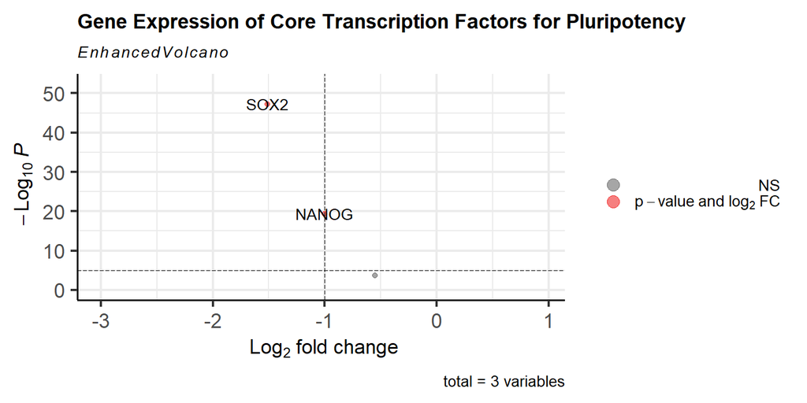

```r
# create volcano plot for:
# core transcription factors: NANOG, OCT4, SOX2
core_TF <- res[rownames(res) %in% c("NANOG", "SOX2", "POU5F1"),]


# create volcano plot, label all genes
EnhancedVolcano(core_TF,
                lab = rownames(core_TF),
                x = 'log2FoldChange',
                y = 'pvalue',
                title = 'Gene Expression of Core Transcription Factors for Pluripotency',
                legendPosition = 'right')
```

```r
NA
NA
```

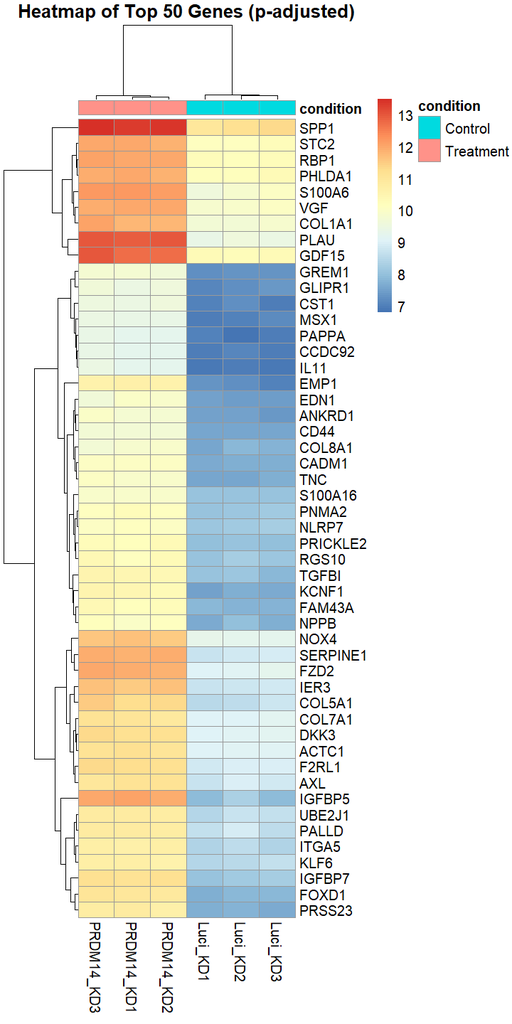

```r
#  heatmap
library(pheatmap)

top50 <- res[order(res$padj),][1:50,] # select top 50 genes

top50 <- row.names(top50)

pheatmap(assay(rld)[top50,], cluster_rows = TRUE, show_rownames = TRUE, cluster_cols = TRUE, annotation_col = coldata, main = "Heatmap of Top 50 Genes (p-adjusted)")
```

```r
top10
```

[output not shown]

The heatmap shows the genes with the top 50 smallest adjusted p-values. A smaller adjusted p-value represents a greater statistical significance in the change in gene expression.

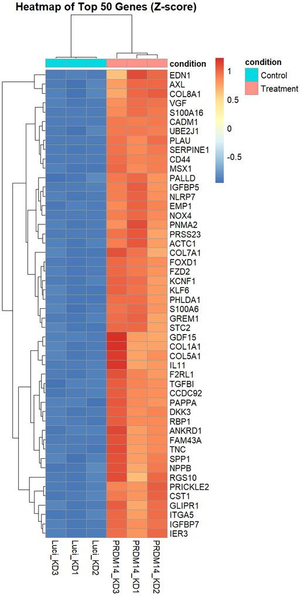

```r
# define function to calculate z-score
calculate_zscore <- function(x) {
  (x - mean(x)) / sd(x)
}

# calculate z-score for each gene
zscore  <- t(apply(normal_counts, 1, calculate_zscore))

zscore_top <- zscore[top50,]

# heatmap
pheatmap(zscore_top, cluster_rows = TRUE, show_rownames = TRUE, cluster_cols = TRUE, annotation_col = coldata, main = "Heatmap of Top 50 Genes (Z-score)")
```

A z-score represents a gene’s expression level compared to the mean expression level. A positive z-score indicates that the gene expression is upregulated, and a negative z-score indicates that the gene expression is downregulated. The heatmap shows that the genes with the top 50 smallest adjusted p-values are upregulated in the treatment group (PRDM14 knockdown) compared to the control group.

```r
zscore_top
```

```
           Luci_KD1   Luci_KD2   Luci_KD3 PRDM14_KD1 PRDM14_KD2 PRDM14_KD3
PLAU     -0.9201705 -0.9012841 -0.9153202  0.8484275  0.9584081  0.9299392
IGFBP5   -0.9192479 -0.8933831 -0.9186591  1.0316728  0.8038888  0.8957285
SERPINE1 -0.9284144 -0.9080555 -0.9009915  0.8632363  0.9281913  0.9460339
FOXD1    -0.9255882 -0.9046925 -0.9050244  0.9187503  0.8317554  0.9847993
EMP1     -0.8989175 -0.9097479 -0.9255628  1.0129700  0.8697571  0.8515011
IGFBP7   -0.9292737 -0.9085767 -0.8970004  0.8211007  0.9356290  0.9781212
IER3     -0.9259027 -0.9109029 -0.8965083  0.7995733  0.9778037  0.9559370
PRSS23   -0.9042253 -0.9020508 -0.9179316  1.0576089  0.7364231  0.9301757
FZD2     -0.9291828 -0.9187275 -0.8863624  0.9277912  0.8182799  0.9882016
KCNF1    -0.9283853 -0.8970846 -0.9045939  0.9532952  0.7704339  1.0063348
NOX4     -0.9007076 -0.9177776 -0.9179842  0.9761867  0.8529669  0.9073158
COL5A1   -0.9238143 -0.9104859 -0.8777488  0.7383731  0.8221465  1.1515294
GDF15    -0.8943161 -0.9061103 -0.8971619  0.7662854  0.7185639  1.2127390
F2RL1    -0.9291153 -0.8940862 -0.9043450  0.8764877  0.7875532  1.0635055
FAM43A   -0.9018452 -0.9155189 -0.9092141  0.7916583  0.8598732  1.0750467
CADM1    -0.9165298 -0.9074102 -0.9146462  0.9071679  0.9147437  0.9166746
TGFBI    -0.8974805 -0.8887207 -0.9456581  0.8744019  0.8267912  1.0306662
DKK3     -0.9276131 -0.9202490 -0.8845200  0.8305396  0.8734560  1.0283864
GREM1    -0.9246983 -0.8952744 -0.9076152  1.0113146  0.7483703  0.9679029
VGF      -0.9374445 -0.9166169 -0.8819420  0.9614389  0.9335713  0.8409932
ITGA5    -0.9236698 -0.8758790 -0.9309031  0.7748838  0.9616455  0.9939227
PRICKLE2 -0.9238431 -0.8870810 -0.9205459  0.8146287  1.0340389  0.8828024
TNC      -0.9118206 -0.9251276 -0.8860540  0.7693684  0.8598549  1.0937789
ANKRD1   -0.8962870 -0.8943590 -0.9303535  0.7632029  0.8518718  1.1059248
AXL      -0.9468605 -0.8713879 -0.9104398  0.9870729  0.9810641  0.7605512
UBE2J1   -0.9576533 -0.8711862 -0.9086450  0.9179614  0.8972335  0.9222896
KLF6     -0.9359586 -0.9231842 -0.8724292  0.9430145  0.7897938  0.9987637
SPP1     -0.9523966 -0.8985670 -0.8733642  0.7598132  0.8934366  1.0710780
CST1     -0.9213798 -0.8737268 -0.9366616  0.8029820  1.0165346  0.9122516
ACTC1    -0.9326496 -0.8965778 -0.8976946  1.0540497  0.7650721  0.9078002
CD44     -0.9155948 -0.9083137 -0.9134815  0.8774609  0.8939226  0.9660065
MSX1     -0.9340103 -0.9224332 -0.8795663  0.8569649  0.8988337  0.9802112
EDN1     -0.8893004 -0.9059758 -0.9084547  1.0996153  0.9855185  0.6185970
CCDC92   -0.9155174 -0.8890133 -0.9281287  0.8640269  0.8404432  1.0281893
S100A6   -0.9649975 -0.9090558 -0.8578334  0.9852109  0.8010865  0.9455894
RBP1     -0.9080300 -0.9342940 -0.8907491  0.8626377  0.8465207  1.0239147
PAPPA    -0.8872075 -0.9450678 -0.8966778  0.8514840  0.8199737  1.0574955
GLIPR1   -0.9416886 -0.9152691 -0.8666265  0.7246018  0.9725602  1.0264221
NPPB     -0.9376933 -0.8534892 -0.9297758  0.7306558  0.9136209  1.0766816
PNMA2    -0.9293272 -0.9077450 -0.8876358  1.0893299  0.8006258  0.8347523
IL11     -0.9051041 -0.8959487 -0.9070448  0.7532182  0.7809479  1.1739314
COL1A1   -0.9251907 -0.9072335 -0.8672338  0.7506956  0.7441729  1.2047896
PALLD    -0.9347194 -0.8478278 -0.9504441  0.9860884  0.8189600  0.9279429
NLRP7    -0.9250228 -0.9144356 -0.8942878  1.0121383  0.8291914  0.8924166
S100A16  -0.9136012 -0.9082226 -0.9155414  0.9528876  0.9244367  0.8600409
COL8A1   -0.9512043 -0.8762393 -0.8952402  0.9865786  1.0190362  0.7170689
COL7A1   -0.9266120 -0.9300835 -0.8613531  0.9400427  0.7018224  1.0761834
PHLDA1   -0.9273080 -0.9264152 -0.8786078  0.9726893  0.7914762  0.9681654
STC2     -0.9295067 -0.9342305 -0.8629511  0.9903938  0.7450482  0.9912464
RGS10    -0.9384648 -0.8573220 -0.9107339  0.6333967  0.9879121  1.0852120
```

**Step 4. Gene Ontology Analysis**

```r
# Find top 50 genes for GO analysis
top50 <- res[order(res$padj),][1:50,]

#print top50 gene names
top50 <- row.names(top50)

#print top50 as list with commas
paste(top50, collapse = ", ")
```

```
[1] "PLAU, IGFBP5, SERPINE1, FOXD1, EMP1, IGFBP7, IER3, PRSS23, FZD2, KCNF1, NOX4, COL5A1, GDF15, F2RL1, FAM43A, CADM1, TGFBI, DKK3, GREM1, VGF, ITGA5, PRICKLE2, TNC, ANKRD1, AXL, UBE2J1, KLF6, SPP1, CST1, ACTC1, CD44, MSX1, EDN1, CCDC92, S100A6, RBP1, PAPPA, GLIPR1, NPPB, PNMA2, IL11, COL1A1, PALLD…
```

Input the above top 50 genes into PANTHER (http://pantherdb.org/) to perform GO analysis.

```r
# read in GO analysis results: pantherChart.txt
panther <- read.table("pantherChart.txt", header = TRUE, sep = "\t")
panther
```

| X1 | transcription.regulator.activity..GO.0140110. | X3 | X5.6. | X6.7. |
| --- | --- | --- | --- | --- |
| 2 | molecular transducer activity (GO:0060089) | 4 | 7.4% | 8.9% |
| 3 | binding (GO:0005488) | 20 | 37.0% | 44.4% |
| 4 | structural molecule activity (GO:0005198) | 4 | 7.4% | 8.9% |
| 5 | molecular function regulator activity (GO:0098772) | 7 | 13.0% | 15.6% |
| 6 | catalytic activity (GO:0003824) | 6 | 11.1% | 13.3% |
| 7 | transporter activity (GO:0005215) | 1 | 1.9% | 2.2% |

```r
NA
```

```r
# find panther column names
colnames(panther)
```

```
[1] "X1"                                            "transcription.regulator.activity..GO.0140110."
[3] "X3"                                            "X5.6."
[5] "X6.7."
```

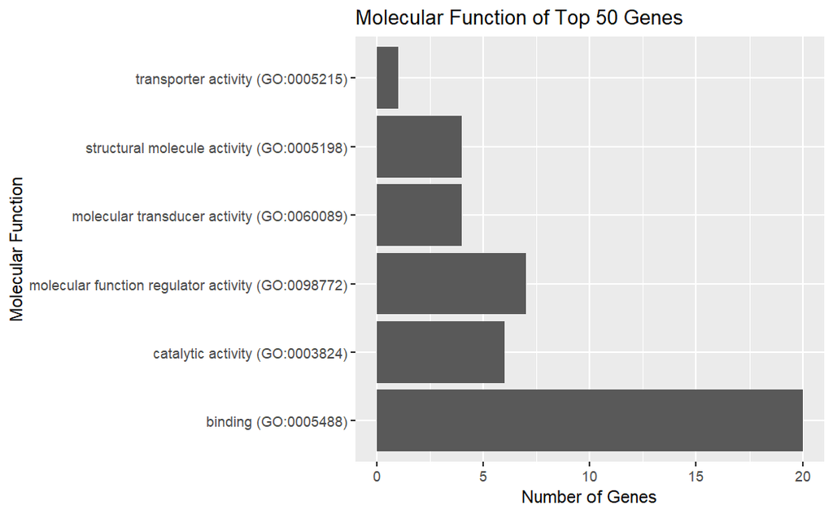

```r
# plot bar chart of panther, where x-axis is the number of genes (x3) and y-axis is the GO term (transcription.regulator.activity..GO.0140110.)

library(ggplot2)

goplot <- ggplot(data = panther, aes(x = X3, y = transcription.regulator.activity..GO.0140110.)) +
  geom_bar(stat = "identity") +
  labs(x = "Number of Genes", y = "Molecular Function") +
  ggtitle("Molecular Function of Top 50 Genes")

goplot
```

```r
NA
NA
```

```r
# panther chart enriched pathways

panther_pathway <- read.table("pantherChart_pathway.txt", header = TRUE, sep = "\t")
panther_pathway
```

| X1 | Cadherin.signaling.pathway..P00012. | X2 | X3.7. | X6.9. |
| --- | --- | --- | --- | --- |
| 2 | Blood coagulation (P00011) | 2 | 3.7% | 6.9% |
| 3 | Interleukin signaling pathway (P00036) | 1 | 1.9% | 3.4% |
| 4 | Integrin signalling pathway (P00034) | 5 | 9.3% | 17.2% |
| 5 | Angiogenesis (P00005) | 1 | 1.9% | 3.4% |
| 6 | Alzheimer disease-presenilin pathway (P00004) | 3 | 5.6% | 10.3% |
| 7 | p53 pathway (P00059) | 1 | 1.9% | 3.4% |
| 8 | Inflammation mediated by chemokine and cytokine signaling pathway (P00031) | 1 | 1.9% | 3.4% |
| 9 | Huntington disease (P00029) | 1 | 1.9% | 3.4% |
| 10 | Wnt signaling pathway (P00057) | 3 | 5.6% | 10.3% |
| 11 | TGF-beta signaling pathway (P00052) | 1 | 1.9% | 3.4% |

[output cut: 5 more lines]

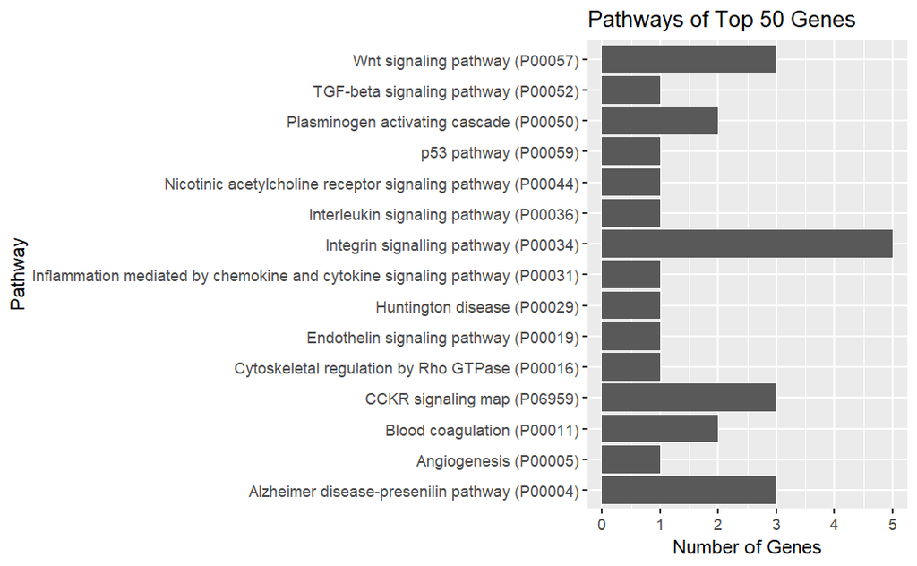

```r
library(ggplot2)

goplot <- ggplot(data = panther_pathway, aes(x = X2, y = Cadherin.signaling.pathway..P00012.)) +
  geom_bar(stat = "identity") +
  labs(x = "Number of Genes", y = "Pathway") +
  ggtitle("Pathways of Top 50 Genes")

goplot
```